### Scripts

```r
source("Random forest algorithm.R", local = knitr::knit_global())
source("Predictive performance assessment.R", local = knitr::knit_global())
```

### Dataset

```r
PB_predictors_data <- read.csv("Data/Phase behaviour and descriptors (25 pc step).csv")
```

The dataset was split into a training/testing (`TT_data`) and validation subset comprising 21 and 7 phase diagrams, respectively. Only the training/testing dataset was used for feature selection and random forest training.

```r
TT_data <- filter(PB_predictors_data, Set == "Training")
```

A list of all phase behaviour predictor names was created and the phase behaviour variable was encoded as a factor.

```r
predictors_all <- colnames(TT_data[, 3:66][, -(4:6)])
TT_data$Phase.behaviour <- factor(as.character(TT_data$Phase.behaviour))
```

### Feature selection using a genetic algorithm

#### Method

To determe the optimum subset of compositional and molecular descriptors, the *caret* genetic feature selection algorithm *ga* was employed. The algorithm was trained over 250 iterations of 50 chromosomes each and the cross-over and mutation rates were set at 0.8 and 0.1, respectively. The fitness of each model was assessed using a custom function, which accounts both for the model's prediction AUC (the higher the AUC - the higher the model fitness) and the number of predictors employed in the random forest structure (the lower the number of predictors - the higher the model fitness) with the former contributing twice as much as the latter to the fitness estimate.

```r
# Genetic algorithm with desirability internal fitness estimate
run_genetic_algorithm <- function(training_testing_data, predictors) {

  # Customise fitness estimate functions
  rfGA_desirability <- rfGA

  rfGA_desirability$fitness_intern <- function (object, x, y, maximize, p) {
    ROC <- auc(roc(predict(object, x), as.numeric(y)))
    dROC <- dMax(0.8, 1) # Maximize ROC
    dPredictors <- dMin(11, p, 2) # Minimize number of predictors (scaling factor 2)
    overall <- dOverall(dROC, dPredictors)
    D <- predict(overall, data.frame(ROC, ncol(x)))
    c(D = D, ROC = as.vector(ROC))
  }

  rfGA_desirability$fitness_extern <- twoClassSummary # Obtain classification performance metrics

  # Genetic algorithm control function
  gaCtrl_desirability <- gafsControl(functions = rfGA_desirability,
                                     method = "cv",
                                     number = 10,
                                     metric = c(internal = "D", external = "ROC"),
                                     maximize = c(internal = TRUE, external = TRUE),
                                     returnResamp = "final",
                                     allowParallel = TRUE,
                                     genParallel = TRUE)


  rf_ga_desirability <- gafs(training_testing_data[,predictors],
                             training_testing_data$Phase.behaviour,
                             # Genetic algorithm controls
                             iters = 250,
                             popSize = 50,
                             pcrossover = 0.8,
                             pmutation = 0.1,
                             elite = 0,
                             gafsControl = gaCtrl_desirability,
                             # Random forest controls
                             ntree=50)

  return(rf_ga_desirability)
}
```

```r
rf_ga_desirability <- run_genetic_algorithm(TT_data, predictors_all)
saveRDS(rf_ga_desirability, file = "Results/GA feature selection results (250, 50, 0.8, 0.1, 0).RDS")
```

#### Results

The changes in random forest fitness with training generation are shown below. The internal and external estimates refer to the fitness values obtained on the 9/10 and 1/10 of the training data, respectively, via the 10-fold cross-validation.

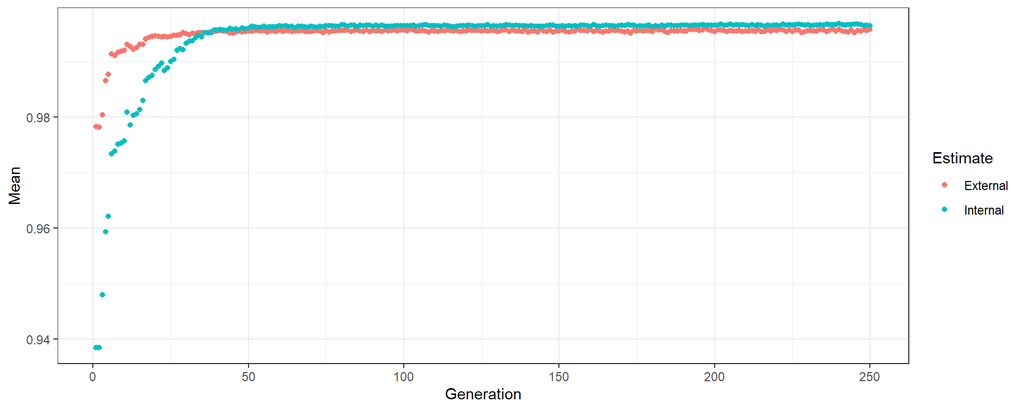

The output of the genetic algorithm feature selection is as follows.

```
##
## Genetic Algorithm Feature Selection
##
## 8547 samples
## 61 predictors
## 2 classes: 'Microemulsion', 'Nonmicroemulsion'
##
## Maximum generations: 250
## Population per generation: 50
## Crossover probability: 0.8
## Mutation probability: 0.1
## Elitism: 0
##
## Internal performance values: D, ROC
## Subset selection driven to maximize internal D
##
## External performance values: ROC, Sens, Spec
## Best iteration chose by maximizing external ROC
## External resampling method: Cross-Validated (10 fold)
##
## During resampling:
##   * the top 5 selected variables (out of a possible 61):
##     NPS.concentration (100%), PS.concentration (100%), SPC.concentration (100%), G2u_dragon_NPS (40%), E2s_dragon_NPS (30%)
##   * on average, 9 variables were selected (min = 9, max = 9)
##
## In the final search using the entire training set:
##    * 16 features selected at iteration 197 including:
##      PS.concentration, NPS.concentration, SPC.concentration, Hydrogen.Bond.Donor.Count_PS, Hydrogen.Bond.Acceptor.Count_PS ...
##    * external performance at this iteration is
##
##         ROC        Sens        Spec
##      0.9961      0.9598      0.9697
```

The following 16 compositional and molecular descriptors were selected:

```
##  [1] "PS.concentration"                "NPS.concentration"
##  [3] "SPC.concentration"               "Hydrogen.Bond.Donor.Count_PS"
##  [5] "Hydrogen.Bond.Acceptor.Count_PS" "AmphM_PS"
##  [7] "CIC3_dragon_PS"                  "L1v_dragon_PS"
##  [9] "Ds_dragon_PS"                    "nOHs_dragon_PS"
## [11] "ASP.4_padel_PS"                  "FNSA.2_padel_PS"
## [13] "MOMI.XY_padel_PS"                "SIC3_dragon_NPS"
## [15] "G2u_dragon_NPS"                  "WNSA.1_padel_NPS"
```

### Random forest models employing selected predictors

A random forest model employing the selected predictors was trained and evaluated on a randomly selected 70% and 30% of the training/testing data, respectively.

```r
for (i in 1:20) {
    model_performance_ga <- run_random_forest(TT_data, ga_predictors, model_performance_ga,
        "RF - GA predictors", i)
}
```

```
## The average AUC achieved by the random forest models (n = 20) on the training data was 0.9997 ± 3e-04
```

```
## The average AUC achieved by the random forest models (n = 20) on the testing data was 0.9656 ± 0.0042
```